# Reinforcement Learning

## What is reinforcement learning?

Let's start by importing some libraries:

```python
# Import necessary libraries
%matplotlib inline

import time
import main_agent
import ten_arm_env
import numpy as np
import pandas as pd
from tqdm import tqdm
import matplotlib.pyplot as plt
from rlglue.rl_glue import RLGlue
```

In your daily life, you are constantly faced with information (i.e. *states of your environment*) and are required to make decisions (i.e. *take actions*). The actions you take are meant to move you closer to your ultimate goal in life (whatever that may be); moreover, these actions in turn affect your environment and thus the subsequent information you might encounter.

The key idea behind **reinforcement learning (RL)** is to use feedback from the environment in the form of *rewards or punishments* to train an agent for a certain task. Similar to what a child experiences while it is growing up, we want to take a "trial-and-error" approach with the enviroment and learn what our optimal decisions (i.e. *policies*) should be.

[figure not shown]

## Sequential decision-making

In RL, the agent generates its own training data by interacting with the world. The agent must learn the consequences of their own actions by trial-and-error, rather than being told the correct action at each step. Let's introduce this evaluative aspect of RL with an example:

[figure not shown]

**Reinforcement learning is not supervised or unsupervised learning.**

Suppose that this woman is choosing her favorite ice cream. She starts by selecting a ramdon desert and then rates it with an emoji. After a while, she begins to prefer one type of ice cream, and either only eats that ice cream type from now on, or continues with the random selection and exploring her options. If she only eats one ice cream type, then she wouldn't be able to collect data on the other options. Perhaps one of the other ice creams is better, or could be to her in the future.

This example is a case of the **$k$-armed bandit problem**. In this problem, we have an agent that chooses between $k$ different actions, and receives a reward acording to the action it chooses. In our examples the agent is the woman, and the $k$ different actions are the different types of ice cream she could order. Each action or ice cream type choice will generate a different reward.

### Action-values

For our agent to decide which action is optimal or best, we most know the reward from taking that action. We call this mapping the **action-value function**:

\begin{equation*} \large Q_*(a) \doteq \mathbb{E}[R_t|A_t=a] \forall a \in {1,\dots,k} \end{equation*}

\begin{equation*} \large = \sum_r p(r|a)\times r \end{equation*}

The optimal action-value function is defined as the expected reward when taking action $a_i$ for each possible action $i\in\{1,\dots,k\}$. The goal of our agent is to maximize the expected reward:

\begin{equation*} \DeclareMathOperator*{\argmax}{arg\,max} \large \argmax\limits_{a} Q_*(a) \end{equation*}

### Sample-average method

However, we don't actually know this function $Q_*$! It is *unknown* to our agent since at the beginning we don't have any information. One possible way of estimating the action-value function is:

\begin{equation*} \large Q(a) \doteq \frac{\text{sum of rewards when $a$ is taken before time $t$}}{\text{Number of times we took $a$ before time $t$}} \end{equation*}

\begin{equation*} \large = \frac{\sum_{i=1}^{t-1}R_i}{t-1} \end{equation*}

Let's assume that our agent receives a reward of 1 if she likes the ice cream she tried that particular time, and 0 otherwise. What would our action-value function estimation look like for 6 time steps?

```python
# intialise data of lists.
data = {'Icecream Cone' : [1,np.nan,0,np.nan,np.nan,1],\
        'Sundae'        : [np.nan,0,np.nan,1,np.nan,np.nan],\
        "Banana split"  : [np.nan,np.nan,np.nan,np.nan,1,np.nan]}

# Create DataFrame
df = pd.DataFrame(data, index=np.linspace(0,5,6).astype(int))
df
```

|  | Icecream Cone | Sundae | Banana split |
| --- | --- | --- | --- |
| 0 | 1.0 | NaN | NaN |
| 1 | NaN | 0.0 | NaN |
| 2 | 0.0 | NaN | NaN |
| 3 | NaN | 1.0 | NaN |
| 4 | NaN | NaN | 1.0 |
| 5 | 1.0 | NaN | NaN |

```python
df.mean()
```

```
Icecream Cone    0.666667
Sundae           0.500000
Banana split     1.000000
dtype: float64
```

As our agent takes more actions, our estimates will get closer and closer to the real values of $Q_*$. Generalizing the calculation above, we can keep track of the sample average of our rewards as follows:

\begin{equation*} \large Q_{n+1}= \frac{1}{n}\sum_{i=1}^{n}R_i \end{equation*}

We can pull the current reward out of the sum. We could write our next value estimate in terms of the previous value estimate - for this, we multiply and divide by $n - 1$. The last term is by definition our current value estimate. With a little bit of algebra we end up with a recursive way of updating our action-value function; this is formally known as the **incremental update rule**.

\begin{equation*} \large \begin{aligned} Q_{n+1}&= \frac{1}{n}\sum_{i=1}^{n}R_i \\ &= \frac{1}{n}\left({\color{Red} R_n} + {\color{Blue} \sum_{i=1}^{n-1}{R_i}}\right)\\ &= \frac{1}{n}\left({\color{Red} R_n} + {\color{Blue} (n-1) \frac{1}{n-1}\sum_{i=1}^{n-1}R_i }\right)\\ &= \frac{1}{n}\left({\color{Red} R_n} + {\color{Blue} (n-1) Q_n}\right)\\ Q_{n+1}&= {\color{Blue} Q_n} + \frac{1}{n}\left({\color{Red} R_n} - {\color{Blue} Q_n}\right) \end{aligned} \end{equation*}

\begin{equation*} \large \text{New estimate}=\text{Old estimate}+\text{Step size}[\text{Target - Old estimate}] \end{equation*}

### Action selection

In reality, our agent woudn't choose an action randomly. Rather, it would choose what it believes is the best ice cream acording to its experience up to that point. This method of choosing actions is known as the **greedy** action selection approach. If the agent only chooses the greedy action, this would be considered an **exploitation** approach. However, it could also choose non-greedy actions with a certain probability $\epsilon$ to get more information on the other action-values - this is known as a **exploration** approach. A combination of both is formaly known as an **$\epsilon$-greedy method**.

## Solving the $k$-armed bandit problem

### Greedy agent

Let's first implement an agent that takes a purely greedy approach.

First we are going to implement the argmax function, which takes in a list of action values and returns an action with the highest value. Why are we implementing our own function instead of using the argmax function that `numpy` uses? Well, `numpy`'s argmax function returns the first instance of the highest value. We do not want that to happen as it biases the agent to choose a specific action in the case of ties. Instead we want to break ties between the highest values randomly:

```python
def our_argmax(q_values):
    """
    Input: list of q_values
    Returns: Index of the item with the highest value. Breaks ties randomly.
    """
    value = float("-inf")
    breaks = []

    for i in range(len(q_values)):
        if q_values[i]>value:
            value=q_values[i]
            breaks = []
        if q_values[i]==value:
            breaks.append(i)
    return np.random.choice(breaks)
```

Now we introduce the first part of an RL-Glue agent that you will implement. Here we are going to create a `GreedyAgent` and implement the `agent_step()` method. This method gets called each time the agent takes a step. The method has to return the action selected by the agent. This method also ensures the agent’s estimates are updated based on the signals it gets from the environment:

```python
class GreedyAgent(main_agent.Agent):
    def agent_step(self, reward, observation):
        """
        The function agent_step takes in a reward and observation and
        returns the action the agent chooses at that time step.

        Input
        reward: the reward the agent gets from the environment after the last action.
        observation: The state the agents obverves.
        Returns: The action chosen by the agent at the current time step.
        """
        #Number of times we visited each arm (action)
        self.arm_count[self.last_action]+=1

        #Step Size
        step_size=1/self.arm_count[self.last_action]

        #Incremental update rule
        self.q_values[self.last_action]=self.q_values[self.last_action]+step_size*(reward-self.q_values[self.last_action])

        present_action = our_argmax(self.q_values)

        self.last_action = present_action

        return present_action
```

Let's visualize the result. Here we run an experiment using RL-Glue to test our agent:

```python
num_runs = 250                    # The number of times the experiment is runned
num_steps = 1200                  # The number of times our agent eats each ice cream ("Number of pulls on each arm")
env = ten_arm_env.Environment     # Ten K-armed bandit environment (RLglue)
agent = GreedyAgent               # Selection of the agent
agent_info = {"num_actions": 10}  # Number of arms ("Ice cream types") our agent has
env_info = {}                     # We create the empty environment

my_averages = []
our_best_average = 0

for run in tqdm(range(num_runs)):           # tqdm is what creates the progress bar below
    np.random.seed(run)

    rl_glue = RLGlue(env, agent)          # We create a new RLGlue experiment with the env and agent we chose above
    rl_glue.rl_init(agent_info, env_info) # We pass RLGlue its requirements to initialize the agent and environment
    rl_glue.rl_start()                    # Vamonos!!

    our_best_average += np.max(rl_glue.environment.arms)

    score = [0]
    average = []

    for i in range(num_steps):
        reward, _, action, _ = rl_glue.rl_step() # The environment and agent take a step and returns the reward, and action taken.
        score.append(score[-1] + reward)
        average.append(score[-1] / (i + 1))
    my_averages.append(average)
```

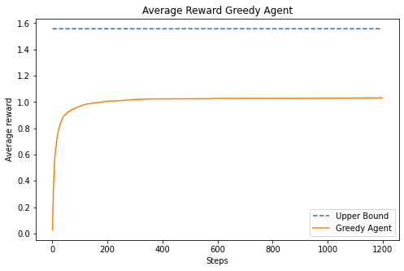

```
[0.02737734 0.11205184 0.19564203 ... 1.03137854 1.0314513  1.03142173]
```

```python
plt.figure(figsize=(8, 5))
plt.plot([our_best_average / num_runs for _ in range(num_steps)], linestyle="--")
plt.plot(np.mean(my_averages, axis=0))
plt.legend(["Upper Bound", "Greedy Agent"])
plt.title("Average Reward Greedy Agent")
plt.xlabel("Steps")
plt.ylabel("Average reward")
plt.show()
greedy_average_reward = np.mean(my_averages, axis=0)
print(greedy_average_reward)
```

### $\epsilon$-greedy agent

Next, let's model an agent that takes the $\epsilon$-greedy approach:

```python
class eGreedyAgent(main_agent.Agent):
    def agent_step(self, reward, observation):
        """
        The function agent_stpe takes in a reward and observation and
        returns the action the agent chooses at that time step.

        Input:
        reward: the reward the agent recieved from the environment after taking the last action.
        observation: the observed state the agent is in.
        Returns:
        current_action: the action chosen by the agent at the current time step.
        """

        #Action value update
        self.arm_count[self.last_action]+=1

        step_size=1/self.arm_count[self.last_action]

        #Incremental update rule

        self.q_values[self.last_action]=self.q_values[self.last_action]+step_size*(reward-self.q_values[self.last_action])

        #Action Selection (e-greedy approach)
        our_prob = np.random.random()
        if our_prob < self.epsilon:
            current_action = np.random.choice(self.num_actions)
        else:
            current_action = our_argmax(self.q_values)

        self.last_action = current_action

        return current_action
```

Let's visualize the result. Here we run an experiment using RL-Glue to test our agent:

```python
num_runs = 250
num_steps = 1200
epsilon = 0.1
agent = eGreedyAgent
env = ten_arm_env.Environment
agent_info = {"num_actions": 10, "epsilon": epsilon}
env_info = {}
my_averages = []

for run in tqdm(range(num_runs)):
    np.random.seed(run)

    rl_glue = RLGlue(env, agent)
    rl_glue.rl_init(agent_info, env_info)
    rl_glue.rl_start()

    scores = [0]
    averages = []
    for i in range(num_steps):
        reward, _, action, _ = rl_glue.rl_step()
        scores.append(scores[-1] + reward)
        averages.append(scores[-1] / (i + 1))
    my_averages.append(averages)
```

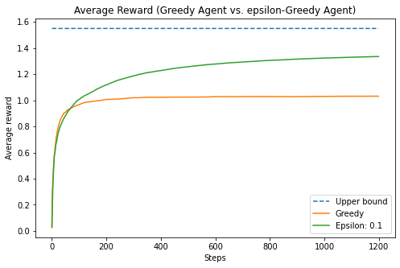

```python
plt.figure(figsize=(8, 5))
plt.plot([1.55 for _ in range(num_steps)], linestyle="--")
plt.plot(greedy_average_reward)
plt.title("Average Reward (Greedy Agent vs. epsilon-Greedy Agent)")
plt.plot(np.mean(my_averages, axis=0))
plt.legend(("Upper bound", "Greedy", "Epsilon: 0.1"))
plt.xlabel("Steps")
plt.ylabel("Average reward")
plt.show()
```

### Averaging multiple runs

You may have noticed that we average the results over 250 runs. Why do you think we did that?

To get some insight, let's look at the results of four individual runs by the same agent:

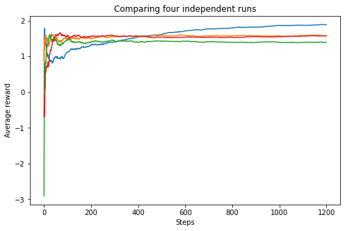

```python
agent = eGreedyAgent
env = ten_arm_env.Environment
agent_info = {"num_actions": 10, "epsilon": 0.1}
env_info = {}
plt.figure(figsize=(8,5), facecolor='white')
num_steps = 1200

for run in (0,1,2,3):
    np.random.seed(run)
    averages = []
    rl_glue = RLGlue(env, agent)
    rl_glue.rl_init(agent_info, env_info)
    rl_glue.rl_start()

    scores = [0]
    for i in range(num_steps):
        reward, state, action, is_terminal = rl_glue.rl_step()
        scores.append(scores[-1] + reward)
        averages.append(scores[-1] / (i + 1))

    plt.plot(averages)

plt.title("Comparing four independent runs")
plt.xlabel("Steps")
plt.ylabel("Average reward")
plt.show()
```

Notice how the four runs are different due to randomness in the environment and the agent. The results will vary depending on the action the agent randomly starts with, or when it randomly chooses to explore. Even if the agent chooses the same action, the reward is randomly sampled from a Gaussian distribution. So there are many sources of variability that it makes sense to average over.

To be more concrete, let’s look at how many times an exploratory action is taken, for different seeds:

```python
print("Random Seed 1")
np.random.seed(1)
for _ in range(20):
    if np.random.random() < 0.1:
        print("I am exploring on this step")


print("\n Random Seed 2")
np.random.seed(2)
for _ in range(20):
    if np.random.random() < 0.1:
        print("I am exploring on this step")
```

```
Random Seed 1
I am exploring on this step
I am exploring on this step
I am exploring on this step

 Random Seed 2
I am exploring on this step
I am exploring on this step
```

With the first seed, we take an exploratory action 3 times out of 20, but with the second, we only take an exploratory action 2 times out of 20. This can significantly affect the performance of our agent.

### Comparing different values of $\epsilon$

Can we do better than an $\epsilon$ of 0.1? Let's try several different values for $\epsilon$ and see how they perform:

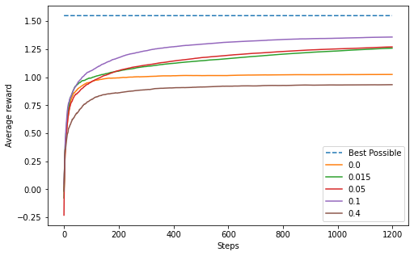

```python
epsilons = [0.0, 0.015,0.05, 0.1, 0.4]

plt.figure(figsize=(8,5))
plt.plot([1.55 for _ in range(num_steps)], linestyle="--")

n_q_values = []
n_averages = []
n_best_actions = []

num_runs = 170

for epsilon in epsilons:
    all_averages = []
    for run in tqdm(range(num_runs)):
        agent = eGreedyAgent
        agent_info = {"num_actions": 10, "epsilon": epsilon}
        env_info = {"random_seed": run}

        rl_glue = RLGlue(env, agent)
        rl_glue.rl_init(agent_info, env_info)
        rl_glue.rl_start()

        best_arm = np.argmax(rl_glue.environment.arms)

        scores = [0]
        averages = []
        my_best_action = []

        for i in range(num_steps):
            reward, state, action, is_terminal = rl_glue.rl_step()
            scores.append(scores[-1] + reward)
            averages.append(scores[-1] / (i + 1))

        all_averages.append(averages)

    plt.plot(np.mean(all_averages, axis=0))

plt.legend(["Best Possible"] + epsilons)
plt.xlabel("Steps")
plt.ylabel("Average reward")
plt.show()
```

[figure not shown]

## Agent Class

```
from rlglue.agent import BaseAgent
import numpy as np

class Agent(BaseAgent):

    def __init__(self):
        self.last_action = None
        self.num_actions = None
        self.q_values = None
        self.step_size = None
        self.epsilon = None
        self.initial_value = 0.0
        self.arm_count = [0.0 for _ in range(10)]

    def agent_init(self, agent_info={}):
        self.num_actions = agent_info.get("num_actions", 2)
        self.initial_value = agent_info.get("initial_value", 0.0)
        self.q_values = np.ones(agent_info.get("num_actions", 2)) * self.initial_value
        self.step_size = agent_info.get("step_size", 0.1)
        self.epsilon = agent_info.get("epsilon", 0.0)
        self.last_action = 0

    def agent_start(self, observation):
        self.last_action = np.random.choice(self.num_actions)
        return self.last_action

    def agent_step(self, reward, observation):
        self.last_action = np.random.choice(self.num_actions)
        return self.last_action

    def agent_end(self, reward):
        pass

    def agent_cleanup(self):
        pass

    def agent_message(self, message):
        pass
```

## Environment class

```
#!/usr/bin/env python

from rlglue.environment import BaseEnvironment
import numpy as np

class Environment(BaseEnvironment):

    actions = [0]

    def __init__(self):
        reward = None
        observation = None
        termination = None
        self.reward_obs_term = (reward, observation, termination)
        self.count = 0
        self.arms = []
        self.seed = None

    def env_init(self, env_info={}):

        self.arms = np.random.randn(10)
        local_observation = 0
        self.reward_obs_term = (0.0, local_observation, False)

    def env_start(self):
        return self.reward_obs_term[1]

    def env_step(self, action):
        reward = self.arms[action] + np.random.randn()
        obs = self.reward_obs_term[1]
        self.reward_obs_term = (reward, obs, False)
        return self.reward_obs_term

    def env_cleanup(self):
        pass

    def env_message(self, message):
        if message == "provide current reward":
            return "{}".format(self.reward_obs_term[0])

        return "Error, cant respond to your inquiry"
```